# Evaluating Categorical Predictions

**Here I am going to evaluate a categorical predictions based on a dataset called "Invistico_Airline"**  
This data given by an airline organization. The actual name of the company is not given due to various purposes that's why the name Invistico airlines.  
The dataset consists of the details of customers who have already flown with them. The feedback of the customers on various context and their flight data has been consolidated.

```python
# Import Necessary Libraries
import numpy as np
import random
import pandas as pd
import matplotlib.pyplot as plt
import seaborn as sns
from scipy import stats
from scipy.stats import multivariate_normal, bernoulli, beta, norm
from scipy.stats import ks_2samp
from scipy.special import expit as logistic_sigmoid
import statsmodels.api as sm
import statsmodels.formula.api as smf
from sklearn.datasets import load_iris
from sklearn.linear_model import LogisticRegression
from sklearn.model_selection import train_test_split
from sklearn.metrics import log_loss
from sklearn.metrics import brier_score_loss
from sklearn.model_selection import cross_val_score
from sklearn.metrics import balanced_accuracy_score, brier_score_loss, accuracy_score, roc_auc_score, roc_curve, auc
from sklearn.model_selection import KFold

# Set display option to avoid scientific notation in pandas, show up to 5 decimal points
pd.set_option('display.float_format', lambda x: '%.5f' % x)
# and numpy
np.set_printoptions(suppress=True, precision=5)
```

```python
# Load the dataset of Airline
df = pd.read_csv('Invistico_Airline.csv',low_memory=False)
```

### Data Cleaning & Exploration

```python
# Drop incomplete records
df = df.dropna().reset_index(drop=True)
```

```python
# Replace values with 1 else 0
df['satisfaction'] = df['satisfaction'].replace({'satisfied':1,'dissatisfied':0}).astype(int)

df['Gender'] = df['Gender'] .replace({'Female':0,'Male':1}).astype(int)

df['Customer Type'] = df['Customer Type'] .replace({'disloyal Customer':0,'Loyal Customer':1}).astype(int)

df['Type of Travel'] = df['Type of Travel'] .replace({'Personal Travel':0,'Business travel':1}).astype(int)
```

#### Exclude the `class_matrix` for now .

```python
# One-hot encode class identifiers
class_one_hot = pd.get_dummies(df['Class'], prefix='Class_').astype(int)

# Filtering to get just the class dummy columns
class_columns = [col for col in class_one_hot.columns if col.startswith('Class_')]
class_matrix = class_one_hot[class_columns]
df = df.drop('Class', axis=1)
```

#### Calculate the correlation matrix across the outcome and X.

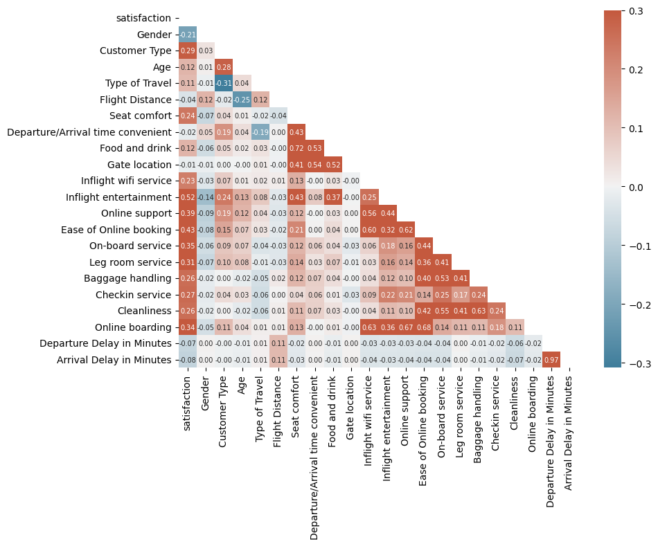

```python
# Add conspiracy_binary as the first column in df to create a combined DataFrame YX
YX = df[['satisfaction'] + [c for c in df.columns if c != 'satisfaction']] # Ensure satisfaction_binary is the first column

# Calculate the Correlation Matrix
corr = YX.corr()

# Plotting
plt.figure(figsize=(10, 8))
mask = np.triu(np.ones_like(corr, dtype=bool))
cmap = sns.diverging_palette(230, 20, as_cmap=True)
sns.heatmap(corr, mask=mask, cmap=cmap, vmax=.3, center=0, annot=True, fmt=".2f", annot_kws={"size": 7})
plt.tight_layout()
plt.show()
```

### Model Assessment and Selection

#### Set up the full design matrix X, this time include the calss_matrix, and a constant.

#### Finally bind the outcome to it and ensure it's the first column of the resulting dataframe.

```python
# Grab relevant features on the heat map above
gender = df['Gender']
customer_type = df['Customer Type']
type_of_travel = df['Type of Travel']
flight_distance = df['Flight Distance']
seat_comfort = df['Seat comfort']
inflight_wifi = df['Inflight wifi service']
inflight_entertainment = df['Inflight entertainment']
checking_service = df['Checkin service']
cleanliness = df['Cleanliness']
departure_delay = df['Departure Delay in Minutes']

# Design matrix
X = pd.concat([
        gender,
        customer_type,
        seat_comfort,
        type_of_travel,
        flight_distance,
        inflight_wifi,
        inflight_entertainment,
        checking_service,
        cleanliness,
        departure_delay,
        class_matrix
], axis=1)

# Add a constant to the feature matrix for statsmodels
X_const = sm.add_constant(X)

# Get full dataset together
YX_const =  pd.concat([df['satisfaction'],X_const],axis = 1)
```

#### Create a validation set (75%) and test set (25%).

#### Ensure the rows of the full dataset selected for each set are chosen at random.

```python
# Split data into validation and test (75:25)

# Calculate 25% of the dataset size
num_samples = YX_const.shape[0]* 25 // 100

# Generate a list of all row IDs
row_ids = list(range(YX_const.shape[0]))

# Randomly select 25% of the row IDs
selected_row_ids = random.sample(row_ids, num_samples)

# Subset to create validation and test
YX_const_test = YX_const[YX_const.index.isin(selected_row_ids)] # the randomly chosen 25% goes to test-set
YX_const_val = YX_const[~YX_const.index.isin(selected_row_ids)] # the remaining 75% is our validation set
```

#### Using a dictionary, define three candidate models in terms of the columns of the design matrix involved in each.

#### The first model is the homogeneous probability model; the second has have all covariates except the classes; the third uses all the columns.

```python
# Define predictors for each model variant
predictors = {
    'a': ['const'],
    'b': [col for col in X_const.columns if not col.startswith('Class_')],
    'c': X_const.columns.tolist()
}
```

```python
y = YX_const_val['satisfaction'] # Target variable

# Define K for cross validation
K = 5

# Setup the KFold cross-validation
kf = KFold(n_splits=K, shuffle=True)

# Initialize a dictionary to store Brier scores
scores = {key: [] for key in predictors}

# Initialize dictionaries to store scores (e.g. Brier score)
brier_scores = {key: [] for key in predictors}
aic_scores = {key: [] for key in predictors}

for key, cols in predictors.items():

    for train_index, test_index in kf.split(YX_const_val):

        # Split into train and test according to the folds
        X_train, X_test = YX_const_val.iloc[train_index][cols], YX_const_val.iloc[test_index][cols]
        y_train, y_test = y.iloc[train_index], y.iloc[test_index]

        # For each fold split, fit the model
        model = sm.Logit(y_train, X_train).fit()

        # Predict probabilities
        y_pred_prob = model.predict(X_test)

        # Calculate Metric
        brier_score = brier_score_loss(y_test, y_pred_prob)
        brier_scores[key].append(brier_score)
        aic_scores[key].append(model.aic)

        # (If you pick a classification metric, you have to use a decision threshold)
        # Convert probabilities to binary predictions (assume simple >0.5 probability as threshold)
        y_pred_binary = (y_pred_prob > 0.5).astype(int)

        print(model.summary())

# Calculate and print the average scores
results = []
for key in predictors.keys():
    average_brier_score = np.mean(brier_scores[key])
    print(average_brier_score)
    average_aic_score = np.mean(aic_scores[key])
    results.append({
        'Model': key,
        'Average Brier Score': average_brier_score,
        'Average AIC': average_aic_score
    })

# Convert results to DataFrame for nicer display
results_df = pd.DataFrame(results)
results_df
```

[output not shown]

[output cut: 225 more lines]

```
const                         -5.8182   3.81e+05  -1.53e-05      1.000   -7.47e+05    7.47e+05
Gender                        -1.0327      0.020    -51.479      0.000      -1.072      -0.993
Customer Type                  2.0017      0.030     67.511      0.000       1.944       2.060
Seat comfort                   0.1376      0.008     17.067      0.000       0.122       0.153
Type of Travel                 0.8212      0.028     29.581      0.000       0.767       0.876
Flight Distance               -0.0001   9.85e-06    -10.878      0.000      -0.000   -8.79e-05
Inflight wifi service          0.2191      0.008     28.635      0.000       0.204       0.234
Inflight entertainment         0.7016      0.009     76.440      0.000       0.684       0.720
Checkin service                0.3192      0.008     38.816      0.000       0.303       0.335
Cleanliness                    0.5202      0.009     57.841      0.000       0.503       0.538
Departure Delay in Minutes    -0.0038      0.000    -13.823      0.000      -0.004      -0.003
Class__Business               -1.4252   3.81e+05  -3.74e-06      1.000   -7.47e+05    7.47e+05
Class__Eco                    -2.1709   3.81e+05   -5.7e-06      1.000   -7.47e+05    7.47e+05
Class__Eco Plus               -2.2222   3.81e+05  -5.83e-06      1.000   -7.47e+05    7.47e+05
==============================================================================================
```

```
Warning: Maximum number of iterations has been exceeded.
         Current function value: 0.422301
         Iterations: 35
                           Logit Regression Results
==============================================================================
Dep. Variable:           satisfaction   No. Observations:                77693
Model:                          Logit   Df Residuals:                    77679
Method:                           MLE   Df Model:                           13
Date:                Sun, 08 Dec 2024   Pseudo R-squ.:                  0.3870
Time:                        22:59:05   Log-Likelihood:                -32810.
converged:                      False   LL-Null:                       -53527.
Covariance Type:            nonrobust   LLR p-value:                     0.000
==============================================================================================
                                 coef    std err          z      P>|z|      [0.025      0.975]
----------------------------------------------------------------------------------------------
const                         -5.8343        nan        nan        nan         nan         nan
Gender                        -1.0578      0.020    -52.491      0.000      -1.097      -1.018
Customer Type                  2.0052      0.030     67.423      0.000       1.947       2.064
Seat comfort                   0.1422      0.008     17.556      0.000       0.126       0.158
Type of Travel                 0.8157      0.028     29.312      0.000       0.761       0.870
Flight Distance               -0.0001    9.9e-06    -10.923      0.000      -0.000   -8.88e-05
Inflight wifi service          0.2200      0.008     28.697      0.000       0.205       0.235
Inflight entertainment         0.7092      0.009     76.963      0.000       0.691       0.727
Checkin service                0.3178      0.008     38.426      0.000       0.302       0.334
Cleanliness                    0.5144      0.009     57.030      0.000       0.497       0.532
Departure Delay in Minutes    -0.0037      0.000    -13.368      0.000      -0.004      -0.003
Class__Business               -1.4091        nan        nan        nan         nan         nan
Class__Eco                    -2.1641        nan        nan        nan         nan         nan
Class__Eco Plus               -2.2612        nan        nan        nan         nan         nan
==============================================================================================
0.24770590794048103
0.13397557067797544
0.1320755169464854
```

|  | Model | Average Brier Score | Average AIC |
| --- | --- | --- | --- |
| 0 | a | 0.24771 | 106991.87326 |
| 1 | b | 0.13398 | 66814.14188 |
| 2 | c | 0.13208 | 65874.14980 |

Because lower brier score and AIC mean that the model has better performance, I choose the third model which includes all features in the X matrix.

#### Re-fit the selected model to the full validation set.

```python
model = sm.Logit(YX_const_val['satisfaction'], YX_const_val[[col for col in YX_const_val.columns if col!= 'satisfaction']]).fit()
```

```python
# Get summary results
summary = model.summary()
print(summary)
```

```
                           Logit Regression Results
==============================================================================
Dep. Variable:           satisfaction   No. Observations:                97116
Model:                          Logit   Df Residuals:                    97102
Method:                           MLE   Df Model:                           13
Date:                Sun, 08 Dec 2024   Pseudo R-squ.:                  0.3845
Time:                        22:59:06   Log-Likelihood:                -41156.
converged:                      False   LL-Null:                       -66869.
Covariance Type:            nonrobust   LLR p-value:                     0.000
==============================================================================================
                                 coef    std err          z      P>|z|      [0.025      0.975]
----------------------------------------------------------------------------------------------
const                         -5.8063        nan        nan        nan         nan         nan
Gender                        -1.0501      0.018    -58.404      0.000      -1.085      -1.015
Customer Type                  2.0017      0.027     75.441      0.000       1.950       2.054
Seat comfort                   0.1365      0.007     18.901      0.000       0.122       0.151
Type of Travel                 0.8227      0.025     33.072      0.000       0.774       0.871
Flight Distance               -0.0001   8.83e-06    -12.026      0.000      -0.000   -8.89e-05
Inflight wifi service          0.2203      0.007     32.158      0.000       0.207       0.234
Inflight entertainment         0.7042      0.008     85.651      0.000       0.688       0.720
Checkin service                0.3158      0.007     42.831      0.000       0.301       0.330
Cleanliness                    0.5154      0.008     64.072      0.000       0.500       0.531
Departure Delay in Minutes    -0.0038      0.000    -15.382      0.000      -0.004      -0.003
Class__Business               -1.4103        nan        nan        nan         nan         nan
Class__Eco                    -2.1555        nan        nan        nan         nan         nan
Class__Eco Plus               -2.2406        nan        nan        nan         nan         nan
==============================================================================================
```

### Model Evaluation and Estimation of Generalisation Error

#### Generate 1000 simulations of the regression coefficients by sampling from the empirical posterior distribution.

```python
# Extract the coefficients (betas) and their covariance matrix from the logistic regression fit
beta_mean = model.params
beta_cov = model.cov_params()

# Number of simulations
n_simulations = 1000

# Simulate beta coefficients
simulated_betas = np.random.multivariate_normal(beta_mean, beta_cov, size=n_simulations)
```

#### For each simulation, generate a predicted probability for the test-set satisfactions.

```python
# Initialize an array to store predictions from each simulation
predictions = np.zeros((n_simulations, YX_const_test.shape[0]))

# Generate predictions for each simulation
for i in range(n_simulations):
    beta_simulation = simulated_betas[i]
    log_odds = np.dot(YX_const_test[[col for col in YX_const_val.columns if col!= 'satisfaction']], beta_simulation)
    probabilities = logistic_sigmoid(log_odds)
    predictions[i] = probabilities
```

#### For the first 20 assessments in the test-set, plot the posterior distirbution of the probabilities.

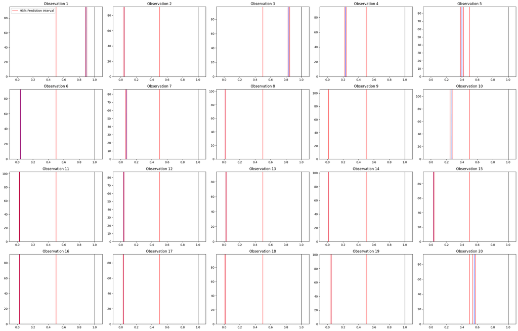

```python
true_labels = YX_const_test['satisfaction']

# Calculate posterior median and the prediction interval for each of the first 10 observations
posterior_medians = np.median(predictions, axis=0)
lower_bounds = np.percentile(predictions, 2.5, axis=0)
upper_bounds = np.percentile(predictions, 97.5, axis=0)

# Plotting with the adjustments for the 90% prediction interval to be shown with red lines
fig, axes = plt.subplots(4, 5, figsize=(25, 16))

for i in range(20):
    ax = axes[i // 5, i % 5]
    # Histogram of simulated probabilities for observation i
    ax.hist(predictions[:, i], bins=30, color='skyblue', edgecolor='white', alpha=0.7)

    # Draw a line for the decision boundary
    ax.axvline(x=0.5, color='red', linestyle='-', linewidth=1)

    # Draw a thick solid black line at the true label position
    true_label_position = 0 if true_labels.iloc[i] == 0 else 1  # Determine the position based on the true label
    ax.axvline(x=true_label_position, color='black', linestyle='-', linewidth=1)

    # Add posterior median
    ax.axvline(x=posterior_medians[i], color='blue', linestyle='-', linewidth=1)

    # Marking the 90% prediction interval with red lines instead of shading
    ax.axvline(x=lower_bounds[i], color='red', linestyle='-', linewidth=1, label='95% Prediction Interval' if i == 0 else "")
    ax.axvline(x=upper_bounds[i], color='red', linestyle='-', linewidth=1)

    ax.set_xlim(-0.1, 1.1)
    ax.set_title(f'Observation {i+1}')
    if i == 0:  # Add legend to the first subplot only to avoid repetition
        ax.legend()

plt.tight_layout()
plt.show()
```

#### Simulate classes (1s or 0s) for the test-set satisfaction assessments, from the posterior predictive distirbution.

```python
# Simulate from the posterior-predictive distirbution
simulated_outcomes = np.random.binomial(1, predictions)
```

#### Calculate the generalisation error for Classification.

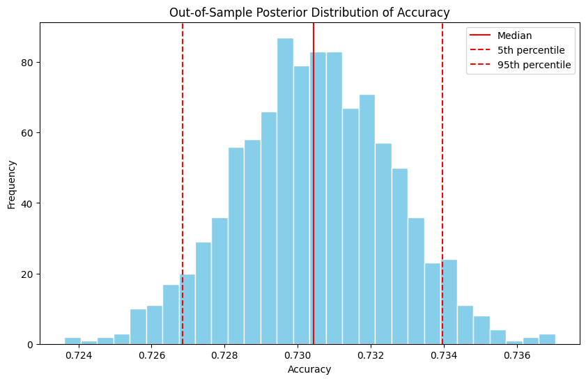

```python
# Calculate accuracy for each simulation
from sklearn.metrics import confusion_matrix

accuracies = []
for i in range(n_simulations):
    accuracy = accuracy_score(true_labels, simulated_outcomes[i])
    accuracies.append(accuracy)

# Plot the histogram of accuracies
plt.figure(figsize=(10, 6))
plt.hist(accuracies, bins=30, color='skyblue', edgecolor='white')
plt.axvline(x=np.median(accuracies), color='red', label='Median')
plt.axvline(x=np.percentile(accuracies, 5), color='red', linestyle='--', label='5th percentile')
plt.axvline(x=np.percentile(accuracies, 95), color='red', linestyle='--', label='95th percentile')
plt.xlabel('Accuracy')
plt.ylabel('Frequency')
plt.title('Out-of-Sample Posterior Distribution of Accuracy')
plt.legend()
plt.show()
```